# BMIN503/EPID600 Project Template

Anahita Davoudi

### Overview

This project uses the publicly available MIMIC-III ICU dataset to study the characteristics of the patients admitted to the Beth Israel Deaconess Medical Center under the category of Thrombotic events. This dataset has been developed by MIT and published around over 60,000 intensive care unit hospitalizations. This dataset includes demographics, vital signs, laboratory tests, medications, and other structured and unstructured data.

Three faculty/staff have been consulted for the definition of the project: - Danielle Mowery: Assistant Professor; Department of Biostatistics, Epidemiology, and Informatics - Emily Schriver: Clinical Informaticist; Data Analytic Center - Sy Hwang: NLP data scientist/programmer; IBI Clinical Research Informatics Core

### Introduction

The thrombotic events have got attention due to COVID-19 recently. The thrombogenicity of COVID-19 has been detected by the high frequency of thrombotic events observed even in Covid-19 patients treated with anticoagulation. The thrombotic events hit every aspect of the circulatory system (e.g., multi-organ and multi-system). The clots can happen anywhere in the body, and we need a better way of identifying and classifying patients. We can achieve that by the qualitative characterizations of this data, looking at overlaps, and the different features between all categories of the thrombotic events.

### Methods

The MIMIC-III dataset contains healthcare data records for over 60,000 patients admitted to the Beth Israel Deaconess Medical Center in Massachusetts from June 2001 - October 2012. This dataset will be used to explore patients characteritics diagnosed with thrombotic events. We define two exclusive patient’s cohort (thrombotic, and bleeding) and study the features of these two cohorts.

Required packages for the project:

```r
library(tm)
library(dplyr)
```

```r
library(ggplot2)
library(wordcloud)
library(RColorBrewer)
library(topicmodels)
library(tidyr)
library(tidyverse)
library(ggraph)
library(igraph)
```

#### Importing data

List of input data from the MIMIC-III dataset:

```r
Admissions      <-  read.csv(file = 'ADMISSIONS.csv')
icdcodes        <- read.csv(file = 'DIAGNOSES_ICDs.csv')
#labs            <- read.csv(file = 'LABEVENTS.csv')
#micro           <- read.csv(file = 'MICROBIOLOGYEVENTS.csv')
#prescriptions   <- read.csv(file = 'PRESCRIPTIONS.csv')
patients        <- read.csv(file = 'PATIENTS.csv')
notes           <- read.csv(file = 'NOTEEVENTSs.csv')
```

#### Data Cleaning

##### Predefined ICD9 Codes

A set of specific ICD9 codes are presented for the two category of thrombotic and bleeding:

```r
icd_thrombotics <- c("452", "4358", "4359", "4536", "4532", "4533", "4510", "36234", "41071", "41091", "41181", "41512", "42979", "43391", "44409", "44481", "45351", "45386", "45382")

icd_bleeding <- c("430", "431", "4230", "4320", "4321", "4560", "5693", "5695", "5789", "37923", "42979", "53501", "53100", "53110", "53120", "53130", "53140", "53150", "53160", "53200", "53210", "53220", "53230", "53240", "53250", "53260", "53270", "53300", "53310", "53320", "53340", "53350", "53360", "53400", "53410", "53420", "53440", "53450", "53460", "56212", "56213", "56201", "56202", "56203", "72992", "56881")
```

##### Varible Selection

```r
#note_cat <- c("Discharge summary", "Radiology")
#notes_new <- subset(notes, CATEGORY %in% note_cat)
#note_new_clipped <- notes_new[,which(colnames(notes_new) %in% c("ROW_ID", "SUBJECT_ID", "HADM_ID", "CATEGORY", "TEXT"))]
#icdcode_clipped <- icdcodes[,which(colnames(icdcodes) %in% c("ROW_ID", "SUBJECT_ID", "HADM_ID", "ICD9_CODE"))]

newicd_thrombo <- subset(icdcodes, ICD9_CODE %in% icd_thrombotics)
newicd_bleed <- subset(icdcodes, ICD9_CODE %in% icd_bleeding)
```

#### Joining Tables

```r
# Merging two tables that represent the two cohorts of thrombotic and bleeding by the two indexes

icd_notes_thrombo <- inner_join(x = notes, y = newicd_thrombo, by = c("SUBJECT_ID", "HADM_ID"))
icd_notes_bleed <- inner_join(x = notes, y = newicd_bleed, by = c("SUBJECT_ID", "HADM_ID"))
```

#### Topic Modeling

As a popular unsupervised method, we used topic Modeling with Latent Dirichlet Allocation (LDA) for discovering latent semantic properties of our cohorts’ notes.

##### Document Cleaning

Neccesary steps before apply the LDA model

1. Creating the corpus
2. Cleaning the corpus (removing punctuations, numbers, stop words, white spaces, etc.)
3. getting rid of very commons words in the text

```r
notes_document <- icd_notes_thrombo%>% select(ROW_ID.x, TEXT)%>% rename(doc_id = ROW_ID.x, text = TEXT)

notes_corpus <- Corpus(DataframeSource(notes_document))

notes_corpus <- tm_map(notes_corpus, removePunctuation, preserve_intra_word_dashes = TRUE)

notes_corpus <- tm_map(notes_corpus, removeNumbers)

notes_corpus <- tm_map(notes_corpus, tolower)

english_stopwords <- readLines("https://slcladal.github.io/resources/stopwords_en.txt", encoding = "UTF-8")

notes_corpus <- tm_map(notes_corpus, removeWords, c(english_stopwords, "admission","discharge","doctor", "hospital", "job", "number", "last", "first", "name", "namepattern", "date", "telephon", "fax", "patient", "left", "right", "man", "woman", "status", "note", "clip", "report", "radiology", "reason", "chest", "report", "medic", "radilog", "admit", "year", "final", "impress", "chang", "unchang", "find", "histori", "present", "portabl"))

notes_corpus <- tm_map(notes_corpus, stemDocument, language = "en")


notes_corpus <- tm_map(notes_corpus, stripWhitespace)
```

##### Building Document Term Matrix

In the LDA model, we need to build a Document Term Matrix (DTM) that contains the number of term occurrences per document. The rows of the DTM represent the documents, and the columns represent the whole vocabulary. Setting a minimum frequency would save overwhelming the system’s memory.

```r
min_freq <- 10000
notes_corpus.dtm <- DocumentTermMatrix(notes_corpus, control = list(bounds = list(global = c(min_freq, Inf))))

rowTotals <- apply(notes_corpus.dtm , 1, sum)

notes_corpus.dtm   <- notes_corpus.dtm[rowTotals> 0, ]

dim(notes_corpus.dtm)
```

```
## [1] 39959    39
```

##### Term Frequency

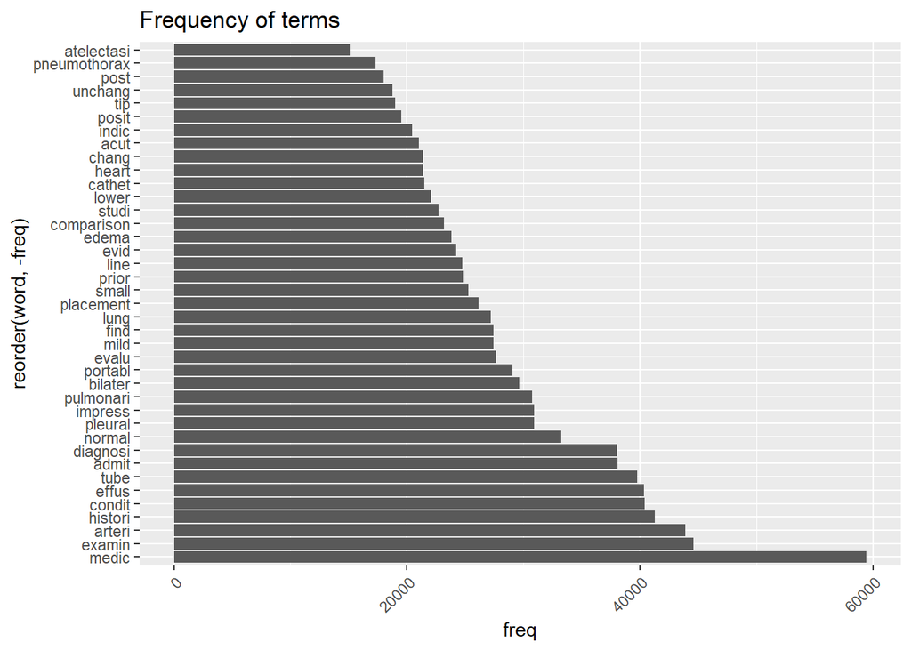

```r
freq <- sort(colSums(as.matrix(notes_corpus.dtm)), decreasing=TRUE)

word.freq <- data.frame(word = names(freq), freq = freq)

ggplot(subset(word.freq, freq > 10000), aes(x = reorder(word, -freq), y = freq)) +
  geom_bar(stat = "identity") + theme(axis.text.x = element_text(angle = 45, hjust = 1)) + coord_flip() + labs(title = "Frequency of terms")
```

##### Word Cloud

```r
#set.seed(2000)

#wordcloud(words = names(freq), freq = freq, min.freq = 10000, max.words=50, random.order=FALSE, rot.per=0.35, colors=brewer.pal(8, "Dark2"))
```

##### LDA topic Modelling

To apply the LDA model, various parameters need to be set, e.g. number of topics, the LDA methods, iterations,etc.

```r
K <- 20
set.seed(2000)
# Gibbs sampling
topicModel <- LDA(notes_corpus.dtm, K, method="Gibbs", control=list(iter = 1000, verbose = 50))
```

```
## K = 20; V = 39; M = 39959
## Sampling 1000 iterations!
## Iteration 50 ...
## Iteration 100 ...
## Iteration 150 ...
## Iteration 200 ...
## Iteration 250 ...
## Iteration 300 ...
## Iteration 350 ...
## Iteration 400 ...
## Iteration 450 ...
## Iteration 500 ...
## Iteration 550 ...
## Iteration 600 ...
## Iteration 650 ...
## Iteration 700 ...
## Iteration 750 ...
## Iteration 800 ...
## Iteration 850 ...
## Iteration 900 ...
## Iteration 950 ...
## Iteration 1000 ...
## Gibbs sampling completed!
```

##### Topic Terms

```r
terms(topicModel, 10)
```

```
##       Topic 1     Topic 2        Topic 3      Topic 4      Topic 5    Topic 6   Topic 7      Topic 8      Topic 9      Topic 10     Topic 11       Topic 12    Topic 13     Topic 14     Topic 15    Topic 16       Topic 17     Topic 18     Topic 19   Topic 20
##  [1,] "bilater"   "placement"    "studi"      "evalu"      "cathet"   "histori" "normal"     "unchang"    "examin"     "lung"       "effus"        "acut"      "chang"      "evid"       "pulmonari" "pneumothorax" "arteri"     "examin"     "lower"    "tube"
##  [2,] "small"     "line"         "prior"      "diagnosi"   "posit"    "heart"   "mild"       "examin"     "condit"     "effus"      "pleural"      "medic"     "admit"      "find"       "edema"     "portabl"      "post"       "condit"     "medic"    "portabl"
##  [3,] "impress"   "tip"          "find"       "admit"      "tip"      "medic"   "histori"    "comparison" "admit"      "atelectasi" "atelectasi"   "histori"   "condit"     "impress"    "heart"     "examin"       "bilater"    "admit"      "admit"    "posit"
##  [4,] "post"      "pneumothorax" "medic"      "find"       "diagnosi" "post"    "medic"      "portabl"    "diagnosi"   "pleural"    "bilater"      "prior"     "medic"      "diagnosi"   "bilater"   "condit"       "medic"      "diagnosi"   "diagnosi" "tip"
##  [5,] "admit"     "posit"        "impress"    "condit"     "admit"    "admit"   "comparison" "condit"     "find"       "impress"    "medic"        "normal"    "diagnosi"   "admit"      "diagnosi"  "indic"        "normal"     "find"       "condit"   "post"
##  [6,] "effus"     "condit"       "comparison" "examin"     "post"     "impress" "line"       "diagnosi"   "indic"      "portabl"    "evalu"        "examin"    "examin"     "indic"      "portabl"   "comparison"   "diagnosi"   "indic"      "examin"   "placement"
##  [7,] "evalu"     "find"         "small"      "impress"    "condit"   "condit"  "posit"      "admit"      "comparison" "find"       "find"         "studi"     "portabl"    "condit"     "mild"      "impress"      "comparison" "comparison" "impress"  "diagnosi"
##  [8,] "mild"      "normal"       "evid"       "comparison" "impress"  "effus"   "unchang"    "indic"      "impress"    "heart"      "normal"       "post"      "comparison" "comparison" "line"      "atelectasi"   "indic"      "impress"    "post"     "atelectasi"
##  [9,] "condit"    "effus"        "post"       "indic"      "medic"    "edema"   "placement"  "impress"    "medic"      "bilater"    "small"        "heart"     "prior"      "examin"     "studi"     "admit"        "lower"      "medic"      "find"     "effus"
## [10,] "pulmonari" "histori"      "unchang"    "tip"        "indic"    "bilater" "chang"      "find"       "small"      "diagnosi"   "pneumothorax" "placement" "pulmonari"  "medic"      "chang"     "acut"         "studi"      "lung"       "effus"    "studi"
```

```r
# the figure for coherence and prevalence score in the Topic Model
```

```r
# Dendogram (distance between 2 probability vectors)
```

#### n-grams

```r
text_bigrams <- notes_document %>% tidytext::unnest_tokens(bigram, text, token = "ngrams", n = 2)

bigrams_sep <- text_bigrams %>% separate(bigram, c("word1", "word2"), sep = " ")
```

#### Sentiment Analysis

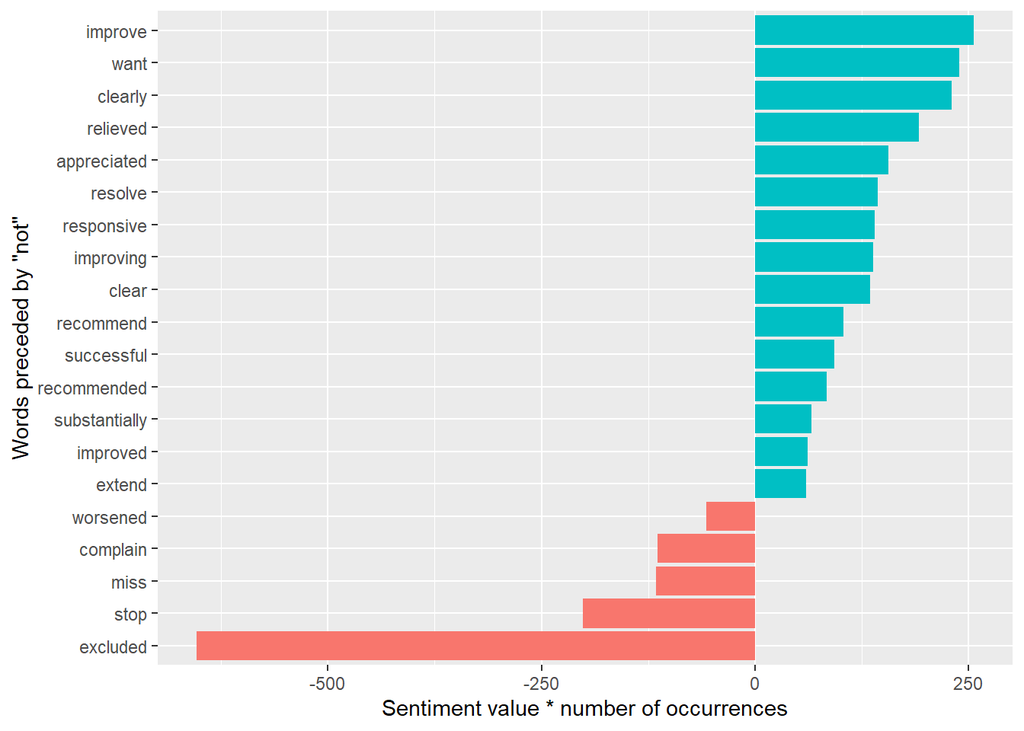

```r
AFINN <- tidytext::get_sentiments("afinn")

not_set <- bigrams_sep %>% filter(word1 == "not") %>% inner_join(AFINN, by = c(word2 = "word")) %>% count(word2, value, sort = TRUE)


not_set %>% mutate(contribution = n * value) %>% arrange(desc(abs(contribution))) %>% head(20) %>% mutate(word2 = reorder(word2, contribution)) %>%
  ggplot(aes(n * value, word2, fill = n * value > 0)) + geom_col(show.legend = FALSE) + labs(x = "Sentiment value * number of occurrences",
       y = "Words preceded by \"not\"")
```

```r
#negation_words <- c("not", "no", "never", "without")

#negated_words <- bigrams_separated %>%
#  filter(word1 %in% negation_words) %>%
#  inner_join(AFINN, by = c(word2 = "word")) %>%
#  count(word1, word2, value, sort = TRUE)
```

#### Cohort Analysis

variable in different tables are analyzed. All codes are shown here.

```r
all_codes <- c("4320", "4321", "430", "431", "72992","37923", "42979", "4230", "4230", "41512", "452", "45351", "45386", "45382", "45382", "4536", "4532", "4533", "4510", "4358", "43391", "36234", "4359", "44409", "44409", "41181", "42979", "41091", "41071", "44481", "5789", "53501", "53100", "53110", "53120", "53130", "53140", "53150", "53160", "53200", "53210", "53220", "53230", "53240", "53250", "53260", "53270", "53300", "53310", "53320", "53340", "53350", "53360", "53400", "53410", "53420", "53440", "53450", "53460", "4560", "56212", "56213", "56213", "5695", "56202", "56203", "56201", "56203", "5693", "56881")

newicd_notes <- subset(icdcodes, ICD9_CODE %in% all_codes)
#icd_notes <- inner_join(x = note_new_clipped, y = newicd_notes, by = c("SUBJECT_ID", "HADM_ID"))
```

##### Cohort Analysis - age

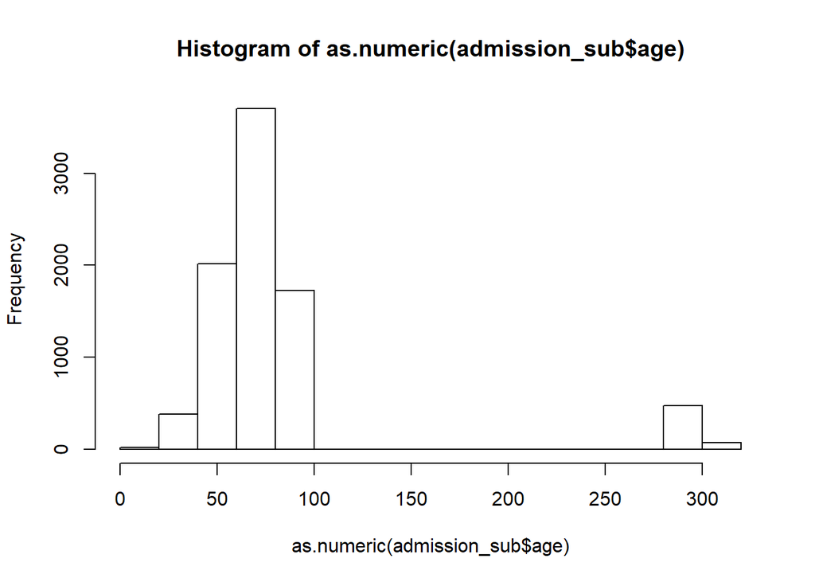

```r
admission_sub = Admissions[Admissions$SUBJECT_ID %in% newicd_notes$SUBJECT_ID & Admissions$HADM_ID %in% newicd_notes$HADM_ID,]
admission_sub = admission_sub %>% distinct(SUBJECT_ID, .keep_all = TRUE)
admission_sub$ADMITTIME = as.POSIXlt(as.character(admission_sub$ADMITTIME), format = "%Y-%m-%d %H:%M:%S")
admission_sub$DISCHTIME = as.POSIXlt(as.character(admission_sub$DISCHTIME), format = "%Y-%m-%d %H:%M:%S")
admission_sub$los = difftime( admission_sub$DISCHTIME, admission_sub$ADMITTIME, units = "days")
admission_sub$birth = NA

for (i in 1:nrow(admission_sub)){
  #print(i)
  admission_sub$birth[i] = as.character(patients$DOB[patients$SUBJECT_ID == admission_sub$SUBJECT_ID[i]])
}
admission_sub$birth = as.POSIXlt(admission_sub$birth, format = "%Y-%m-%d %H:%M:%S")
admission_sub$age = NA
admission_sub$age = difftime(admission_sub$ADMITTIME, admission_sub$birth, units = "days")/365.25
hist(as.numeric(admission_sub$age))
```

```r
length(which(admission_sub$age>100))
```

```
## [1] 550
```

```r
## 550 patients had age >100
```

##### Events’ Subcategories codes

```r
neurological_bleeding <- c("4320", "4321", "430", "431")
Musculoskeletal_bleeding <- c("72992")
Ocular_bleeding <- c("37923")
Cardiac_bleeding <- c("42979", "4230")
Genitourinary_bleeding <- c("4230")
pulmonary_thrombotic <- c("41512")
extremity_thrombotic <- c("452", "45351", "45386", "45382", "45382", "4536", "4532", "4533", "4510")
neurological_thrombotic <- c("4358", "43391", "36234", "4359")
cardiovascular_thrombotic <-  c("44409", "44409", "41181", "42979", "41091", "41071", "44481")
Gastrointestinal_bleeding <- c("5789", "53501", "53100", "53110", "53120", "53130", "53140", "53150", "53160", "53200",
                            "53210", "53220", "53230", "53240", "53250", "53260", "53270", "53300", "53310", "53320",
                             "53340", "53350", "53360", "53400", "53410", "53420", "53440", "53450", "53460", "4560",
                             "56212", "56213", "56213", "5695", "56202", "56203", "56201", "56203", "5693", "56881")
```

### References

MIMIC-III, a freely accessible critical care database. Johnson AEW, Pollard TJ, Shen L, Lehman L, Feng M, Ghassemi M, Moody B, Szolovits P, Celi LA, and Mark RG. Scientific Data (2016). DOI: 10.1038/sdata.2016.35. Available at: http://www.nature.com/articles/sdata201635